# Multilevel Modeling

Modeling Achievement with High School and Beyond

William Murrah

2022-04-11

This notebook documents the use of a multilevel regression framework to model mathematics achievement using the High School and Beyond data. See the documentation for this data in the following directory in this project:

`MultilevelModelingWorkshop/resources/ho_hsb.pdf`

This project and all the necessary materials can be downloaded from the following github page:

https://github.com/auqmer/MultilevelModelingWorkshop

If you don’t know how to use github, just click on the green Code tab then click “Download ZIP”.

The data set can be found in `data/hsb.csv`, which contain data on 7,185 students nested within 160 schools.

### Student level variables:

*minority* - an indicator for student ethnicity (1 = minority, 0 = other)  
*female* - an indicator for student gender (1 = female, 0 = male)  
*ses* - (a standardized scale constructed from variables measuring parental education, occupation, and income)  
*mathach* - a measure of mathematics achievement

### School level variables:

*size* - (school enrollment)  
*sector* - (1 = Catholic, 0 = public)  
*pracad* - (proportion of students in the academic track)  
*disclim* - (a scale measuring disciplinary climate)  
*himnty* - (1 = more than 40% minority enrollment, 0 = less than 40%)  
*meanses* - (mean of the SES values for the students in this school who are included in the level-1 file)

## Exploring HSB Data

### Load and clean the data

```r
# Run the R script to load and clean HSB data:
source("code/cleanHSB.R")

# Create a data set aggregated at the school level
hsb_school        <- aggregate(mathach ~ school, data = hsb, FUN = mean)
hsb_school$ses    <- aggregate(ses     ~ school, data = hsb, FUN = mean)$ses
hsb_school$sector <- aggregate(sector  ~ school, data = hsb, FUN = unique)$sector
hsb_school$size   <- aggregate(size    ~ school, data = hsb, FUN = mean)$size
```

### Visualize key student level variables

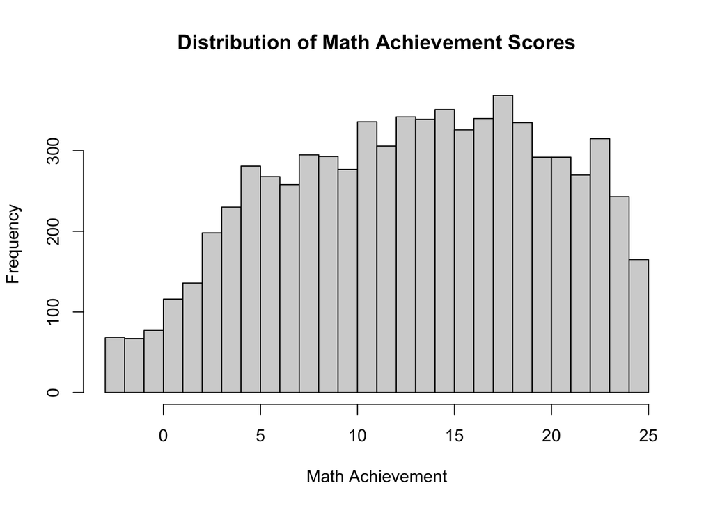

```r
hist(hsb$mathach,
     breaks = "fd",
     main = "Distribution of Math Achievement Scores",
     xlab = "Math Achievement")
```

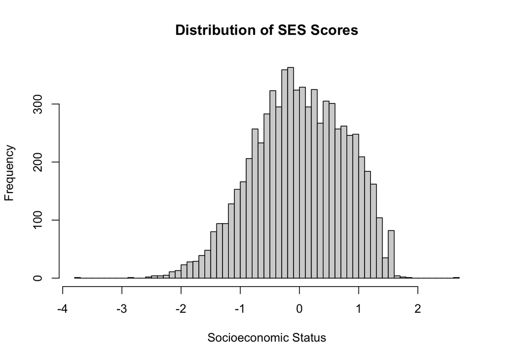

```r
hist(hsb$ses,
     breaks = "fd",
     main = "Distribution of SES Scores",
     xlab = "Socioeconomic Status")
```

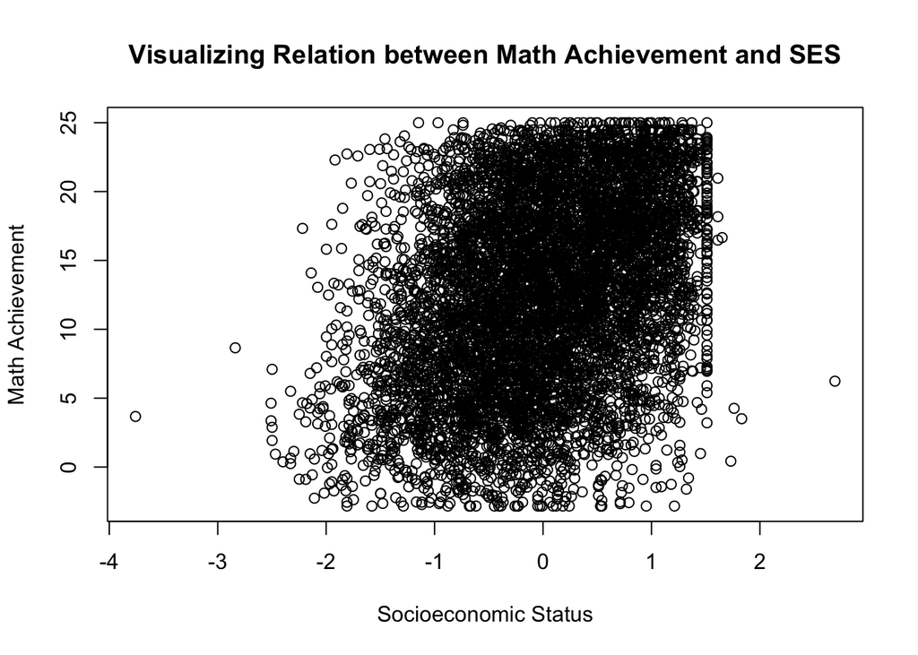

```r
plot(mathach ~ ses,
     data = hsb,
     main = "Visualizing Relation between Math Achievement and SES",
     ylab = "Math Achievement",
     xlab = "Socioeconomic Status")
```

### Do Mean Math and SES vary by School?

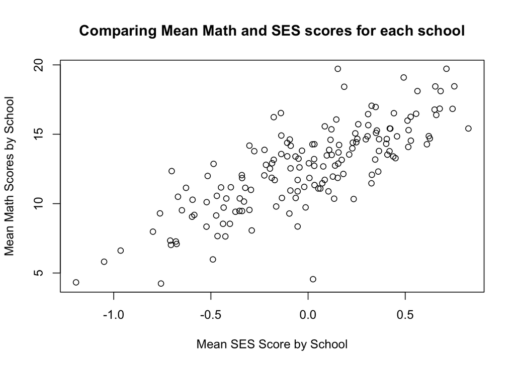

```r
plot(mathach ~ ses,
     data = hsb_school,
     main = "Comparing Mean Math and SES scores for each school",
     ylab = "Mean Math Scores by School",
     xlab = "Mean SES Score by School")
```

```r
describe(hsb, fast = TRUE)
```

```
         vars    n    mean      sd    min     max   range    se
X           1 7185 3593.00 2074.28   1.00 7185.00 7184.00 24.47
school      2 7185     NaN      NA    Inf    -Inf    -Inf    NA
minority    3 7185     NaN      NA    Inf    -Inf    -Inf    NA
female      4 7185     NaN      NA    Inf    -Inf    -Inf    NA
ses         5 7185    0.00    0.78  -3.76    2.69    6.45  0.01
mathach     6 7185   12.75    6.88  -2.83   24.99   27.82  0.08
size        7 7185 1056.86  604.17 100.00 2713.00 2613.00  7.13
sector      8 7185     NaN      NA    Inf    -Inf    -Inf    NA
pracad      9 7185    0.53    0.25   0.00    1.00    1.00  0.00
disclim    10 7185   -0.13    0.94  -2.42    2.76    5.17  0.01
himinty    11 7185     NaN      NA    Inf    -Inf    -Inf    NA
meanses    12 7185    0.01    0.41  -1.19    0.83    2.02  0.00
```

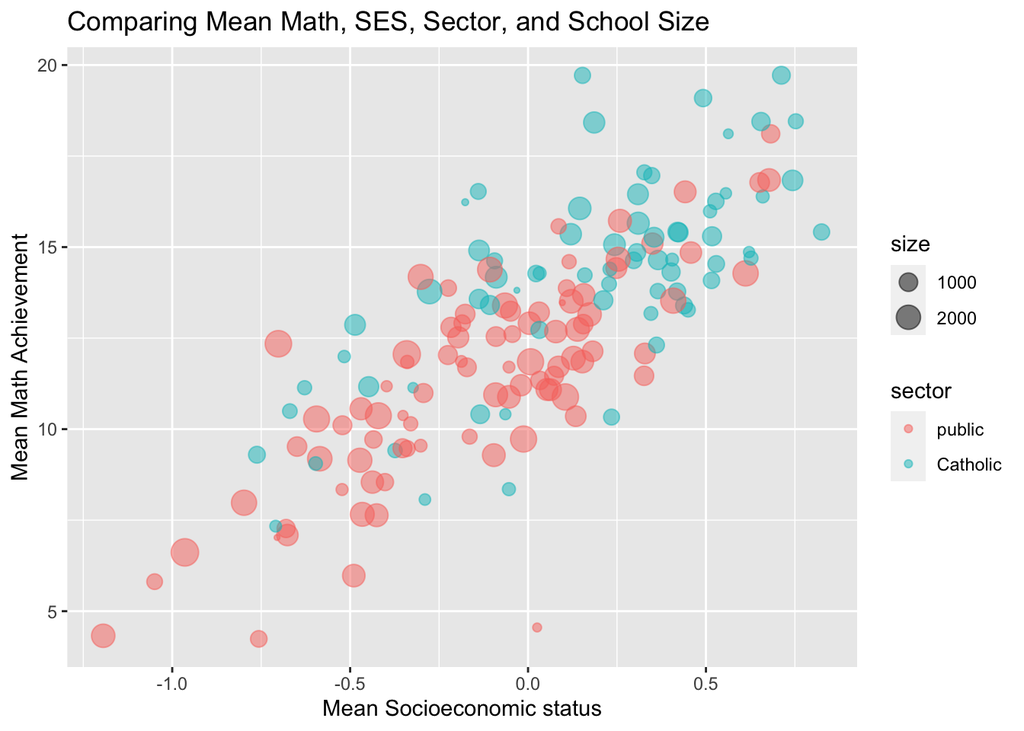

```r
ggplot(hsb_school, aes(x = ses, y = mathach, color = sector, size = size)) +
  geom_point(alpha = .5) + labs(y = "Mean Math Achievement",
                      x = "Mean Socioeconomic status",
                      title = "Comparing Mean Math, SES, Sector, and School Size")
```

## Models

### Empty Model

```r
empty.model <- lmer(mathach ~ 1 + (1|school), data = hsb)
summary(empty.model)
```

```
Linear mixed model fit by REML. t-tests use Satterthwaite's method [
lmerModLmerTest]
Formula: mathach ~ 1 + (1 | school)
   Data: hsb

REML criterion at convergence: 47116.8

Scaled residuals:
    Min      1Q  Median      3Q     Max
-3.0631 -0.7539  0.0267  0.7606  2.7426

Random effects:
 Groups   Name        Variance Std.Dev.
 school   (Intercept)  8.614   2.935
 Residual             39.148   6.257
Number of obs: 7185, groups:  school, 160

Fixed effects:
            Estimate Std. Error       df t value Pr(>|t|)
(Intercept)  12.6370     0.2444 156.6473   51.71   <2e-16 ***
---
Signif. codes:  0 '***' 0.001 '**' 0.01 '*' 0.05 '.' 0.1 ' ' 1
```

```r
8.614/(8.614 + 39.148)
```

```
[1] 0.1803526
```

```r
# in the performance package:
icc(empty.model)
```

```
# Intraclass Correlation Coefficient

     Adjusted ICC: 0.180
  Conditional ICC: 0.180
```

```r
level1.model <- lmer(mathach ~ ses + female + (1 | school), data = hsb)
summary(level1.model)
```

```
Linear mixed model fit by REML. t-tests use Satterthwaite's method [
lmerModLmerTest]
Formula: mathach ~ ses + female + (1 | school)
   Data: hsb

REML criterion at convergence: 46595.7

Scaled residuals:
    Min      1Q  Median      3Q     Max
-3.1769 -0.7375  0.0341  0.7658  2.8048

Random effects:
 Groups   Name        Variance Std.Dev.
 school   (Intercept)  4.492   2.119
 Residual             36.813   6.067
Number of obs: 7185, groups:  school, 160

Fixed effects:
              Estimate Std. Error        df t value Pr(>|t|)
(Intercept)    13.2771     0.2025  215.6474  65.572  < 2e-16 ***
ses             2.3564     0.1054 6795.9187  22.349  < 2e-16 ***
femalefemale   -1.1875     0.1654 6831.0063  -7.178  7.8e-13 ***
---
Signif. codes:  0 '***' 0.001 '**' 0.01 '*' 0.05 '.' 0.1 ' ' 1

Correlation of Fixed Effects:
            (Intr) ses
ses         -0.021
femalefemal -0.426  0.056
```

```r
level1.2.model <- lmer(mathach ~ ses + female +
                         sector + size + disclim + (1 |school),
                       data = hsb)
summary(level1.2.model)
```

```
Linear mixed model fit by REML. t-tests use Satterthwaite's method [
lmerModLmerTest]
Formula: mathach ~ ses + female + sector + size + disclim + (1 | school)
   Data: hsb

REML criterion at convergence: 46559.6

Scaled residuals:
    Min      1Q  Median      3Q     Max
-3.2019 -0.7382  0.0328  0.7570  2.8819

Random effects:
 Groups   Name        Variance Std.Dev.
 school   (Intercept)  3.062   1.750
 Residual             36.813   6.067
Number of obs: 7185, groups:  school, 160

Fixed effects:
                 Estimate Std. Error         df t value Pr(>|t|)
(Intercept)     1.212e+01  4.588e-01  1.582e+02  26.409  < 2e-16 ***
ses             2.339e+00  1.050e-01  6.576e+03  22.279  < 2e-16 ***
femalefemale   -1.238e+00  1.641e-01  6.420e+03  -7.545 5.16e-14 ***
sectorCatholic  1.237e+00  4.725e-01  1.441e+02   2.618 0.009782 **
size            5.509e-04  2.825e-04  1.475e+02   1.950 0.053081 .
disclim        -8.461e-01  2.331e-01  1.519e+02  -3.630 0.000386 ***
---
Signif. codes:  0 '***' 0.001 '**' 0.01 '*' 0.05 '.' 0.1 ' ' 1

Correlation of Fixed Effects:
            (Intr) ses    fmlfml sctrCt size
ses          0.017
femalefemal -0.214  0.059
sectorCthlc -0.656 -0.041  0.041
size        -0.812 -0.011  0.014  0.298
disclim     -0.258  0.041  0.056  0.662 -0.055
```

```r
level1.2.mses.model <- lmer(mathach ~ ses + female +
                         sector + size + disclim + meanses + (1 |school),
                       data = hsb)
summary(level1.2.mses.model)
```

```
Linear mixed model fit by REML. t-tests use Satterthwaite's method [
lmerModLmerTest]
Formula: mathach ~ ses + female + sector + size + disclim + meanses +
    (1 | school)
   Data: hsb

REML criterion at convergence: 46506.1

Scaled residuals:
    Min      1Q  Median      3Q     Max
-3.1980 -0.7305  0.0300  0.7608  2.9007

Random effects:
 Groups   Name        Variance Std.Dev.
 school   (Intercept)  1.992   1.411
 Residual             36.797   6.066
Number of obs: 7185, groups:  school, 160

Fixed effects:
                 Estimate Std. Error         df t value Pr(>|t|)
(Intercept)     1.246e+01  3.960e-01  1.676e+02  31.461  < 2e-16 ***
ses             2.151e+00  1.085e-01  7.024e+03  19.831  < 2e-16 ***
femalefemale   -1.230e+00  1.620e-01  5.714e+03  -7.590 3.73e-14 ***
sectorCatholic  7.185e-01  4.078e-01  1.486e+02   1.762  0.08012 .
size            4.520e-04  2.415e-04  1.538e+02   1.872  0.06315 .
disclim        -6.066e-01  2.017e-01  1.599e+02  -3.008  0.00306 **
meanses         2.884e+00  3.671e-01  1.799e+02   7.855 3.49e-13 ***
---
Signif. codes:  0 '***' 0.001 '**' 0.01 '*' 0.05 '.' 0.1 ' ' 1

Correlation of Fixed Effects:
            (Intr) ses    fmlfml sctrCt size   disclm
ses         -0.010
femalefemal -0.241  0.049
sectorCthlc -0.657  0.002  0.042
size        -0.806  0.001  0.014  0.298
disclim     -0.240  0.003  0.070  0.625 -0.060
meanses      0.096 -0.293  0.036 -0.158 -0.042  0.145
fit warnings:
Some predictor variables are on very different scales: consider rescaling
```

```r
level1.2.mses.re_ses.model <- lmer(mathach ~ ses + female +
                         sector + size + disclim + meanses + (ses |school),
                       data = hsb)
summary(level1.2.mses.re_ses.model)
```

```
Linear mixed model fit by REML. t-tests use Satterthwaite's method [
lmerModLmerTest]
Formula: mathach ~ ses + female + sector + size + disclim + meanses +
    (ses | school)
   Data: hsb

REML criterion at convergence: 46499.9

Scaled residuals:
    Min      1Q  Median      3Q     Max
-3.1697 -0.7268  0.0265  0.7536  2.9059

Random effects:
 Groups   Name        Variance Std.Dev. Corr
 school   (Intercept)  2.0657  1.4372
          ses          0.4207  0.6487   0.38
 Residual             36.5795  6.0481
Number of obs: 7185, groups:  school, 160

Fixed effects:
                 Estimate Std. Error         df t value Pr(>|t|)
(Intercept)     1.239e+01  3.955e-01  1.616e+02  31.317  < 2e-16 ***
ses             2.157e+00  1.208e-01  1.871e+02  17.860  < 2e-16 ***
femalefemale   -1.220e+00  1.621e-01  5.832e+03  -7.523 6.15e-14 ***
sectorCatholic  9.000e-01  4.094e-01  1.459e+02   2.198  0.02952 *
size            4.383e-04  2.398e-04  1.409e+02   1.828  0.06971 .
disclim        -6.483e-01  2.024e-01  1.565e+02  -3.204  0.00164 **
meanses         2.857e+00  3.679e-01  1.673e+02   7.766 7.73e-13 ***
---
Signif. codes:  0 '***' 0.001 '**' 0.01 '*' 0.05 '.' 0.1 ' ' 1

Correlation of Fixed Effects:
            (Intr) ses    fmlfml sctrCt size   disclm
ses          0.036
femalefemal -0.242  0.046
sectorCthlc -0.656  0.002  0.041
size        -0.802  0.001  0.016  0.296
disclim     -0.248  0.001  0.068  0.626 -0.053
meanses      0.102 -0.275  0.036 -0.154 -0.038  0.138
fit warnings:
Some predictor variables are on very different scales: consider rescaling
```

```r
htmlreg(list(empty.model, level1.model, level1.2.model, level1.2.mses.model,
             level1.2.mses.re_ses.model))
```

Statistical models

|  | Model 1 | Model 2 | Model 3 | Model 4 | Model 5 |
| --- | --- | --- | --- | --- | --- |
| (Intercept) | 12.64*** | 13.28*** | 12.12*** | 12.46*** | 12.39*** |
|  | (0.24) | (0.20) | (0.46) | (0.40) | (0.40) |
| ses |  | 2.36*** | 2.34*** | 2.15*** | 2.16*** |
|  |  | (0.11) | (0.10) | (0.11) | (0.12) |
| femalefemale |  | -1.19*** | -1.24*** | -1.23*** | -1.22*** |
|  |  | (0.17) | (0.16) | (0.16) | (0.16) |
| sectorCatholic |  |  | 1.24** | 0.72 | 0.90* |
|  |  |  | (0.47) | (0.41) | (0.41) |
| size |  |  | 0.00 | 0.00 | 0.00 |
|  |  |  | (0.00) | (0.00) | (0.00) |
| disclim |  |  | -0.85*** | -0.61** | -0.65** |
|  |  |  | (0.23) | (0.20) | (0.20) |
| meanses |  |  |  | 2.88*** | 2.86*** |
|  |  |  |  | (0.37) | (0.37) |
| AIC | 47122.79 | 46605.73 | 46575.56 | 46524.11 | 46521.93 |
| BIC | 47143.43 | 46640.13 | 46630.60 | 46586.03 | 46597.60 |
| Log Likelihood | -23558.40 | -23297.86 | -23279.78 | -23253.05 | -23249.96 |
| Num. obs. | 7185 | 7185 | 7185 | 7185 | 7185 |
| Num. groups: school | 160 | 160 | 160 | 160 | 160 |
| Var: school (Intercept) | 8.61 | 4.49 | 3.06 | 1.99 | 2.07 |
| Var: Residual | 39.15 | 36.81 | 36.81 | 36.80 | 36.58 |
| Var: school ses |  |  |  |  | 0.42 |
| Cov: school (Intercept) ses |  |  |  |  | 0.35 |

***p < 0.001; **p < 0.01; *p < 0.05

```r
anova(level1.2.mses.model, level1.2.mses.re_ses.model)
```

```
refitting model(s) with ML (instead of REML)
```

```
Data: hsb
Models:
level1.2.mses.model: mathach ~ ses + female + sector + size + disclim + meanses + (1 | school)
level1.2.mses.re_ses.model: mathach ~ ses + female + sector + size + disclim + meanses + (ses | school)
                           npar   AIC   BIC logLik deviance  Chisq Df
level1.2.mses.model           9 46500 46562 -23241    46482
level1.2.mses.re_ses.model   11 46498 46574 -23238    46476 5.9178  2
                           Pr(>Chisq)
level1.2.mses.model
level1.2.mses.re_ses.model    0.05187 .
---
Signif. codes:  0 '***' 0.001 '**' 0.01 '*' 0.05 '.' 0.1 ' ' 1
```

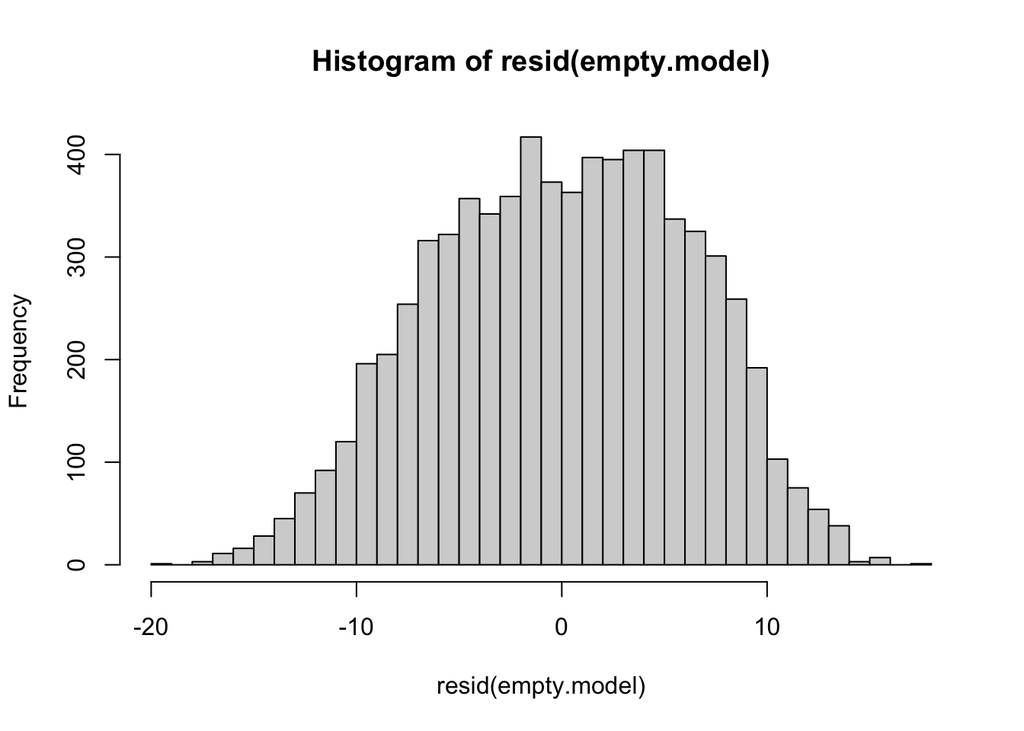

```r
hist(resid(empty.model), breaks = "fd")
```

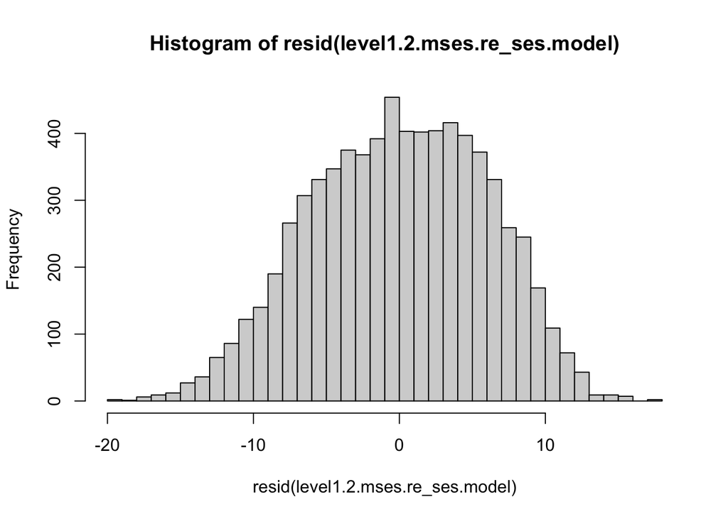

```r
hist(resid(level1.2.mses.re_ses.model), breaks = "fd")
```

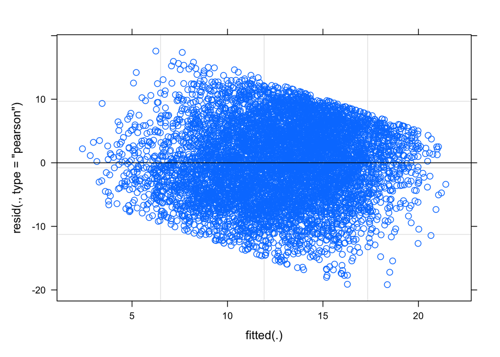

```r
plot(level1.2.mses.re_ses.model)
```

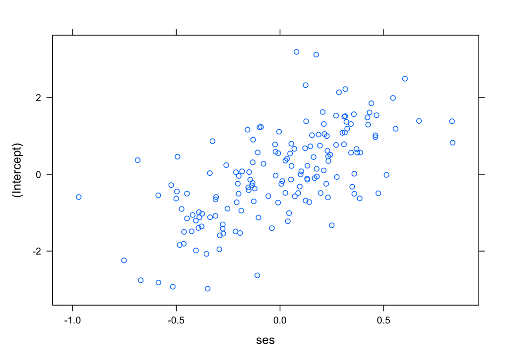

```r
plot(ranef(level1.2.mses.re_ses.model))
```